# dacc-preProcess.R

ana

Wed Oct 11 12:59:08 2017

### Preprocesando el dataset

```r
source("bnlearn-utils.R")
set.seed(147)

library(readr)
sensores <- read_csv("~/phd-repos/tmin/bnlearn/data/estaciones-dacc-diarios.csv")
```

Variables del dataset

```r
colnames(sensores)
```

```
##  [1] "X1"               "date"             "las_paredes.Hmin"
##  [4] "las_paredes.Hmed" "las_paredes.Hmax" "las_paredes.Tmin"
##  [7] "las_paredes.Tmax" "las_paredes.Tmed" "la_llave.Hmin"
## [10] "la_llave.Hmed"    "la_llave.Hmax"    "la_llave.Tmin"
## [13] "la_llave.Tmax"    "la_llave.Tmed"    "tunuyan.Hmin"
## [16] "tunuyan.Hmed"     "tunuyan.Hmax"     "tunuyan.Tmin"
## [19] "tunuyan.Tmax"     "tunuyan.Tmed"     "junin.Tmax"
## [22] "junin.Tmed"       "junin.Tmin"       "junin.Hmax"
## [25] "junin.Hmed"       "junin.Hmin"       "agua_amarga.Tmax"
## [28] "agua_amarga.Tmed" "agua_amarga.Tmin" "agua_amarga.Hmax"
## [31] "agua_amarga.Hmed" "agua_amarga.Hmin" "el_marcado.Tmax"
## [34] "el_marcado.Tmed"  "el_marcado.Tmin"  "el_marcado.Hmax"
## [37] "el_marcado.Hmed"  "el_marcado.Hmin"
```

Una vista breve

```r
head(sensores)
```

```
## # A tibble: 6 x 38
##      X1       date las_paredes.Hmin las_paredes.Hmed las_paredes.Hmax
##   <int>     <date>            <dbl>            <dbl>            <dbl>
## 1     1 2007-03-20         19.37500         22.16667         25.20833
## 2     2 2007-03-21         28.54167         31.00000         33.66667
## 3     3 2007-03-22         57.70833         59.66667         61.87500
## 4     4 2007-03-23         41.00000         43.95833         46.91667
## 5     5 2007-03-24         45.83333         47.91667         50.12500
## 6     6 2007-03-25         44.75000         48.20833         51.25000
## # ... with 33 more variables: las_paredes.Tmin <dbl>,
## #   las_paredes.Tmax <dbl>, las_paredes.Tmed <dbl>, la_llave.Hmin <dbl>,
## #   la_llave.Hmed <dbl>, la_llave.Hmax <dbl>, la_llave.Tmin <dbl>,
## #   la_llave.Tmax <dbl>, la_llave.Tmed <dbl>, tunuyan.Hmin <dbl>,
## #   tunuyan.Hmed <dbl>, tunuyan.Hmax <dbl>, tunuyan.Tmin <dbl>,
## #   tunuyan.Tmax <dbl>, tunuyan.Tmed <dbl>, junin.Tmax <dbl>,
## #   junin.Tmed <dbl>, junin.Tmin <dbl>, junin.Hmax <int>,
## #   junin.Hmed <int>, junin.Hmin <int>, agua_amarga.Tmax <dbl>,
## #   agua_amarga.Tmed <dbl>, agua_amarga.Tmin <dbl>,
## #   agua_amarga.Hmax <int>, agua_amarga.Hmed <int>,
## #   agua_amarga.Hmin <int>, el_marcado.Tmax <dbl>, el_marcado.Tmed <dbl>,
## #   el_marcado.Tmin <dbl>, el_marcado.Hmax <int>, el_marcado.Hmed <int>,
## #   el_marcado.Hmin <int>
```

Cantidad de filas y columnas

```r
cat("Rows: ",nrow(sensores)," Columns: ",ncol(sensores))
```

```
## Rows:  1645  Columns:  38
```

como denomino a las variables que quiero predecir

```r
pred_sensores = colnames(sensores)[c(6,12,18,23,29)]
pred_sensores
```

```
## [1] "las_paredes.Tmin" "la_llave.Tmin"    "tunuyan.Tmin"
## [4] "junin.Tmin"       "agua_amarga.Tmin"
```

reemplazo valor erroneo (temperatura máxima por los 780)

```r
sensores[1632,30:35]
```

```
## # A tibble: 1 x 6
##   agua_amarga.Hmax agua_amarga.Hmed agua_amarga.Hmin el_marcado.Tmax
##              <int>            <int>            <int>           <dbl>
## 1               98               69               25             784
## # ... with 2 more variables: el_marcado.Tmed <dbl>, el_marcado.Tmin <dbl>
```

```r
sensores[1632,33] <- 25
```

Columnas a borrar

```r
erase <- colnames(sensores)[1:2]
erase
```

```
## [1] "X1"   "date"
```

```r
sensores <- sensores[,-which(names(sensores) %in% erase)]
colnames(sensores)
```

```
##  [1] "las_paredes.Hmin" "las_paredes.Hmed" "las_paredes.Hmax"
##  [4] "las_paredes.Tmin" "las_paredes.Tmax" "las_paredes.Tmed"
##  [7] "la_llave.Hmin"    "la_llave.Hmed"    "la_llave.Hmax"
## [10] "la_llave.Tmin"    "la_llave.Tmax"    "la_llave.Tmed"
## [13] "tunuyan.Hmin"     "tunuyan.Hmed"     "tunuyan.Hmax"
## [16] "tunuyan.Tmin"     "tunuyan.Tmax"     "tunuyan.Tmed"
## [19] "junin.Tmax"       "junin.Tmed"       "junin.Tmin"
## [22] "junin.Hmax"       "junin.Hmed"       "junin.Hmin"
## [25] "agua_amarga.Tmax" "agua_amarga.Tmed" "agua_amarga.Tmin"
## [28] "agua_amarga.Hmax" "agua_amarga.Hmed" "agua_amarga.Hmin"
## [31] "el_marcado.Tmax"  "el_marcado.Tmed"  "el_marcado.Tmin"
## [34] "el_marcado.Hmax"  "el_marcado.Hmed"  "el_marcado.Hmin"
```

Procedemos a armar un dataset con las variables, colocando los datos de hace dos días, luego hace un día y luego día presente. Por ello, desfazamos el dataset para que queden primero las variables en T-2, T-1 y luego en t o tiempo presente.

```r
sensores_T_2 <- sensores[1:(nrow(sensores)-2),]
sensores_T_1 <- sensores[2:(nrow(sensores)-1),] # no incluyo la primera fila
sensores_t <- sensores[3:nrow(sensores),]
```

renombro las columnas

```r
colnames(sensores_T_2) <- paste(colnames(sensores_T_2),"_T_2",sep="")
colnames(sensores_T_1) <- paste(colnames(sensores_T_1),"_T_1",sep="")
```

del tiempo presente solo me interesa la temperatura mínima, las que quiero predecir

```r
sensores_t <- sensores_t[,pred_sensores]
colnames(sensores_t) <- paste(colnames(sensores_t),"_t",sep="")
pred_sensores <- paste(pred_sensores,"_t",sep="") # renombro variables predictoras
```

creo dataset de datos de T-2, T-1 y t

```r
df <- cbind.data.frame(sensores_T_2,sensores_T_1,sensores_t)
```

nombres de las variables a usar para entrenar/testear

```r
colnames(df)
```

```
##  [1] "las_paredes.Hmin_T_2" "las_paredes.Hmed_T_2" "las_paredes.Hmax_T_2"
##  [4] "las_paredes.Tmin_T_2" "las_paredes.Tmax_T_2" "las_paredes.Tmed_T_2"
##  [7] "la_llave.Hmin_T_2"    "la_llave.Hmed_T_2"    "la_llave.Hmax_T_2"
## [10] "la_llave.Tmin_T_2"    "la_llave.Tmax_T_2"    "la_llave.Tmed_T_2"
## [13] "tunuyan.Hmin_T_2"     "tunuyan.Hmed_T_2"     "tunuyan.Hmax_T_2"
## [16] "tunuyan.Tmin_T_2"     "tunuyan.Tmax_T_2"     "tunuyan.Tmed_T_2"
## [19] "junin.Tmax_T_2"       "junin.Tmed_T_2"       "junin.Tmin_T_2"
## [22] "junin.Hmax_T_2"       "junin.Hmed_T_2"       "junin.Hmin_T_2"
## [25] "agua_amarga.Tmax_T_2" "agua_amarga.Tmed_T_2" "agua_amarga.Tmin_T_2"
## [28] "agua_amarga.Hmax_T_2" "agua_amarga.Hmed_T_2" "agua_amarga.Hmin_T_2"
## [31] "el_marcado.Tmax_T_2"  "el_marcado.Tmed_T_2"  "el_marcado.Tmin_T_2"
## [34] "el_marcado.Hmax_T_2"  "el_marcado.Hmed_T_2"  "el_marcado.Hmin_T_2"
## [37] "las_paredes.Hmin_T_1" "las_paredes.Hmed_T_1" "las_paredes.Hmax_T_1"
## [40] "las_paredes.Tmin_T_1" "las_paredes.Tmax_T_1" "las_paredes.Tmed_T_1"
## [43] "la_llave.Hmin_T_1"    "la_llave.Hmed_T_1"    "la_llave.Hmax_T_1"
## [46] "la_llave.Tmin_T_1"    "la_llave.Tmax_T_1"    "la_llave.Tmed_T_1"
## [49] "tunuyan.Hmin_T_1"     "tunuyan.Hmed_T_1"     "tunuyan.Hmax_T_1"
## [52] "tunuyan.Tmin_T_1"     "tunuyan.Tmax_T_1"     "tunuyan.Tmed_T_1"
## [55] "junin.Tmax_T_1"       "junin.Tmed_T_1"       "junin.Tmin_T_1"
## [58] "junin.Hmax_T_1"       "junin.Hmed_T_1"       "junin.Hmin_T_1"
## [61] "agua_amarga.Tmax_T_1" "agua_amarga.Tmed_T_1" "agua_amarga.Tmin_T_1"
## [64] "agua_amarga.Hmax_T_1" "agua_amarga.Hmed_T_1" "agua_amarga.Hmin_T_1"
## [67] "el_marcado.Tmax_T_1"  "el_marcado.Tmed_T_1"  "el_marcado.Tmin_T_1"
## [70] "el_marcado.Hmax_T_1"  "el_marcado.Hmed_T_1"  "el_marcado.Hmin_T_1"
## [73] "las_paredes.Tmin_t"   "la_llave.Tmin_t"      "tunuyan.Tmin_t"
## [76] "junin.Tmin_t"         "agua_amarga.Tmin_t"
```

nro de ejemplos

```r
nrow(df)
```

```
## [1] 1643
```

nro de variables

```r
ncol(df)
```

```
## [1] 77
```

black list de aristas

```r
bl <- get_blacklist(pred_sensores)
```

```
## 'data.frame':    0 obs. of  2 variables:
##  $ from: atomic
##   ..- attr(*, "levels")= chr  "las_paredes.Tmin_t" "la_llave.Tmin_t" "tunuyan.Tmin_t" "junin.Tmin_t" ...
##  $ to  : atomic
##   ..- attr(*, "levels")= chr  "las_paredes.Tmin_t" "la_llave.Tmin_t" "tunuyan.Tmin_t" "junin.Tmin_t" ...
```

```r
wl <- get_whitelist(pred_sensores,colnames(df))
```

```
## 'data.frame':    0 obs. of  2 variables:
##  $ from: chr
##  $ to  : chr
```

### Training set y test dataset

```r
df[,1:ncol(df)] <- lapply(df[,1:ncol(df)],as.numeric) # <- convertir a numeric
until <- round(nrow(df)*.67)
training.set = df[1:until, ] # This is training set to learn the parameters
test.set = df[until:nrow(df), ]
until
```

```
## [1] 1101
```

Librería para aprendizaje de redes bayesianas

```r
library(bnlearn)
```

Aprendemos una red bayesiana usando el algoritmo hc y pasando como restricciones las white y black lists

```r
start_time <- Sys.time()
res = hc(training.set, whitelist=wl,blacklist = bl)
end_time <- Sys.time()
end_time - start_time
```

```
## Time difference of 20.3582 secs
```

Aprendizaje de parametros

```r
start_time <- Sys.time()
fitted = bn.fit(res, training.set)     # learning of parameters
end_time <- Sys.time()
end_time - start_time
```

```
## Time difference of 0.09900784 secs
```

guardo modelo para más análisis o corridas posteriores

```r
save(res, file = paste("hc-dacc-t2",Sys.time(),".RData",sep=""))
```

Mostramos los parámetros para los nodos que nos interesan predecir

```r
fitted[pred_sensores]
```

```
## $las_paredes.Tmin_t
##
##   Parameters of node las_paredes.Tmin_t (Gaussian distribution)
##
## Conditional density: las_paredes.Tmin_t | las_paredes.Hmin_T_2 + las_paredes.Hmed_T_2 + las_paredes.Hmax_T_2 + las_paredes.Tmin_T_2 + las_paredes.Tmax_T_2 + las_paredes.Tmed_T_2 + tunuyan.Tmin_T_2 + las_paredes.Hmin_T_1 + las_paredes.Hmed_T_1 + las_paredes.Hmax_T_1 + las_paredes.Tmin_T_1 + las_pa…
## Coefficients:
##          (Intercept)  las_paredes.Hmin_T_2  las_paredes.Hmed_T_2
##          -4.31733619           -0.17060019            0.10431958
## las_paredes.Hmax_T_2  las_paredes.Tmin_T_2  las_paredes.Tmax_T_2
##           0.07263216            0.11142172           -0.24734196
## las_paredes.Tmed_T_2      tunuyan.Tmin_T_2  las_paredes.Hmin_T_1
##          -0.02544744            0.22031121            0.02941268
## las_paredes.Hmed_T_1  las_paredes.Hmax_T_1  las_paredes.Tmin_T_1
##           0.50105131           -0.51805416           -0.16762954
## las_paredes.Tmax_T_1  las_paredes.Tmed_T_1     la_llave.Tmax_T_1
##          -0.12790670            0.46743214            0.33623966
##     tunuyan.Hmed_T_1      tunuyan.Hmax_T_1  agua_amarga.Tmax_T_1
##          -0.31059655            0.33820949            0.17540121
##  el_marcado.Tmax_T_1
##           0.13968555
## Standard deviation of the residuals: 2.77104
##
## $la_llave.Tmin_t
##
##   Parameters of node la_llave.Tmin_t (Gaussian distribution)
##
## Conditional density: la_llave.Tmin_t | la_llave.Hmin_T_2 + la_llave.Hmed_T_2 + la_llave.Hmax_T_2 + la_llave.Tmin_T_2 + la_llave.Tmax_T_2 + la_llave.Tmed_T_2 + tunuyan.Tmin_T_2 + agua_amarga.Tmax_T_2 + la_llave.Hmin_T_1 + la_llave.Hmed_T_1 + la_llave.Hmax_T_1 + la_llave.Tmin_T_1 + la_llave.Tmax_T_…
## Coefficients:
##          (Intercept)     la_llave.Hmin_T_2     la_llave.Hmed_T_2
##          -1.14130752            0.37293567           -1.19846211
##    la_llave.Hmax_T_2     la_llave.Tmin_T_2     la_llave.Tmax_T_2
##           0.81053092            1.10691806           -0.11272572
##    la_llave.Tmed_T_2      tunuyan.Tmin_T_2  agua_amarga.Tmax_T_2
##          -1.00706581            0.25082881           -0.12221157
##    la_llave.Hmin_T_1     la_llave.Hmed_T_1     la_llave.Hmax_T_1
##           0.32852953           -0.36116108            0.05432188
##    la_llave.Tmin_T_1     la_llave.Tmax_T_1     la_llave.Tmed_T_1
##           0.14167581           -0.08644077            0.41568214
## agua_amarga.Tmax_T_1   el_marcado.Tmax_T_1
##           0.16069796            0.21479512
```

[output cut: 44 more lines]

```
##          (Intercept)      tunuyan.Tmin_T_2  agua_amarga.Tmax_T_2
##         -10.08078739            0.14747800           -0.09379677
## agua_amarga.Tmed_T_2  agua_amarga.Tmin_T_2  agua_amarga.Hmax_T_2
##          -0.18513386            0.10239719            0.00163452
## agua_amarga.Hmed_T_2  agua_amarga.Hmin_T_2     la_llave.Tmin_T_1
##           0.01077554           -0.05274841            0.20943953
##     tunuyan.Hmax_T_1        junin.Tmed_T_1        junin.Hmin_T_1
##           0.02590688            0.32215386            0.04229664
## agua_amarga.Tmax_T_1  agua_amarga.Tmed_T_1  agua_amarga.Tmin_T_1
##           0.15289973            0.08403538            0.05384916
## agua_amarga.Hmax_T_1  agua_amarga.Hmed_T_1  agua_amarga.Hmin_T_1
##          -0.01659353            0.04459387            0.01363801
##  el_marcado.Tmax_T_1
##           0.12561848
## Standard deviation of the residuals: 1.959873
```

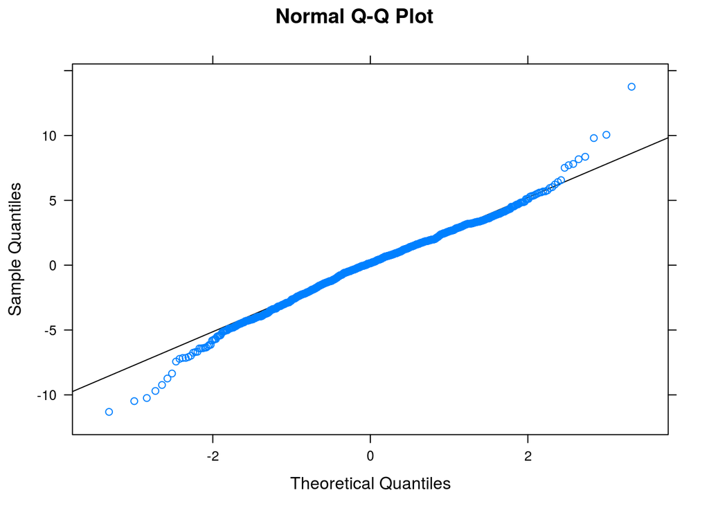

```r
bn.fit.qqplot(fitted$las_paredes.Tmin_t)
```

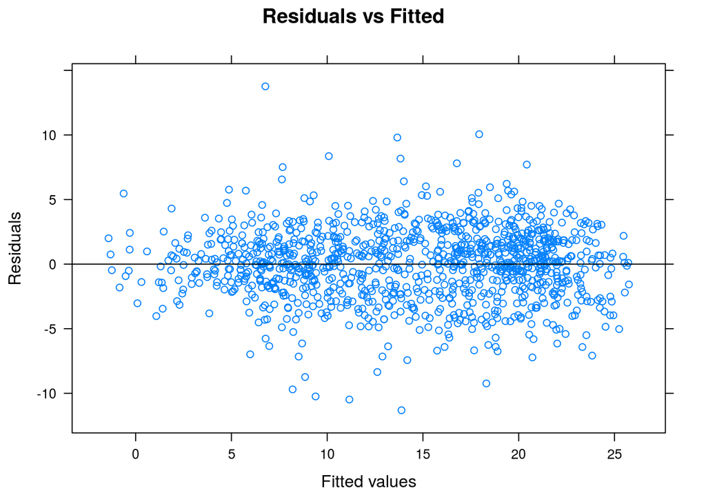

```r
bn.fit.xyplot(fitted$las_paredes.Tmin_t)
```

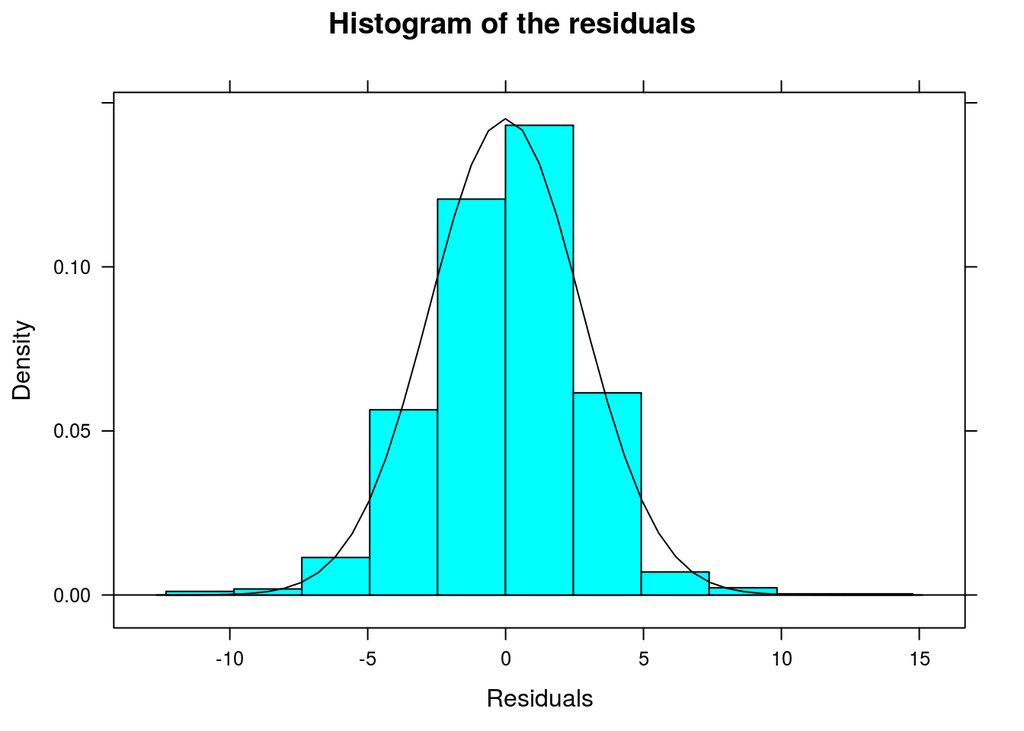

```r
bn.fit.histogram(fitted$las_paredes.Tmin_t)
```

Markov blanket de las variables de interés para predecir

```r
for(i in 1:length(pred_sensores))
{
  cat("Markov blanket of ",pred_sensores[i],"\n")
  print(mb(res,pred_sensores[i]))
}
```

```
## Markov blanket of  las_paredes.Tmin_t
##  [1] "las_paredes.Hmin_T_2" "las_paredes.Hmed_T_2" "las_paredes.Hmax_T_2"
##  [4] "las_paredes.Tmin_T_2" "las_paredes.Tmax_T_2" "las_paredes.Tmed_T_2"
##  [7] "la_llave.Hmin_T_2"    "la_llave.Hmed_T_2"    "la_llave.Hmax_T_2"
## [10] "tunuyan.Tmin_T_2"     "las_paredes.Hmin_T_1" "las_paredes.Hmed_T_1"
## [13] "las_paredes.Hmax_T_1" "las_paredes.Tmin_T_1" "las_paredes.Tmax_T_1"
## [16] "las_paredes.Tmed_T_1" "la_llave.Hmin_T_1"    "la_llave.Hmax_T_1"
## [19] "la_llave.Tmax_T_1"    "tunuyan.Hmed_T_1"     "tunuyan.Hmax_T_1"
## [22] "agua_amarga.Tmax_T_1" "el_marcado.Tmax_T_1"
## Markov blanket of  la_llave.Tmin_t
##  [1] "la_llave.Hmin_T_2"    "la_llave.Hmed_T_2"    "la_llave.Hmax_T_2"
##  [4] "la_llave.Tmin_T_2"    "la_llave.Tmax_T_2"    "la_llave.Tmed_T_2"
##  [7] "tunuyan.Tmin_T_2"     "agua_amarga.Tmax_T_2" "la_llave.Hmin_T_1"
## [10] "la_llave.Hmed_T_1"    "la_llave.Hmax_T_1"    "la_llave.Tmin_T_1"
## [13] "la_llave.Tmax_T_1"    "la_llave.Tmed_T_1"    "agua_amarga.Tmax_T_1"
```

[output cut: 36 more lines]

Predicciones, evaluación en conjunto de testeo

```r
df_res <- errors_regression(pred_sensores, fitted, test.set, verbose = FALSE)
```

```
## Testing on  las_paredes.Tmin_t
## Testing on  la_llave.Tmin_t
## Testing on  tunuyan.Tmin_t
## Testing on  junin.Tmin_t
## Testing on  agua_amarga.Tmin_t
```

```r
df_res
```

```
##             Variable                  ME             RMSE              MAE
## 1 las_paredes.Tmin_t  0.0928694126889401 3.15393672769861 2.36275864981557
## 2    la_llave.Tmin_t  0.0819694215577987 2.87465294984853 2.18774777344671
## 3     tunuyan.Tmin_t   0.532657587379033 2.37502023779364 1.81174190883969
## 4       junin.Tmin_t  0.0864409672855724 2.20873314379135 1.66162063481033
## 5 agua_amarga.Tmin_t -0.0981033121803154 2.13128896279121 1.61355312055907
##                 MPE             MAPE
## 1  7.80303917686647 31.3825064660991
## 2 -12.5233751684784 35.4002703093009
## 3  4.64558672124744 25.5477024149426
## 4              -Inf              Inf
## 5  2.78071975276993 46.3730583561769
```

plots de R squared

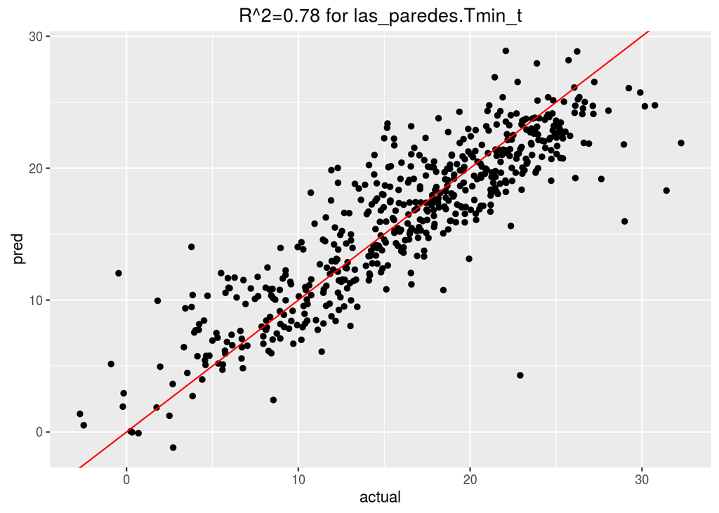

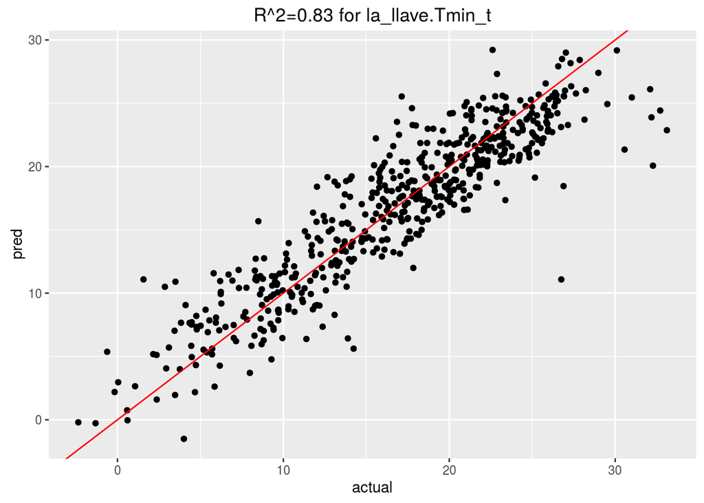

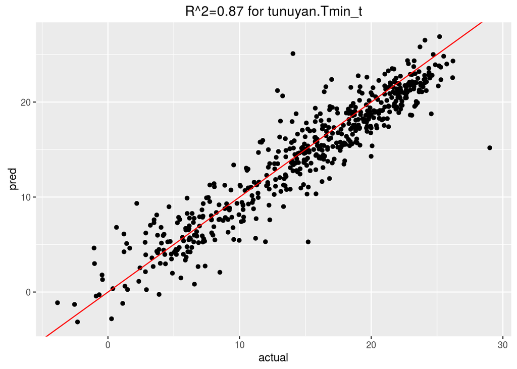

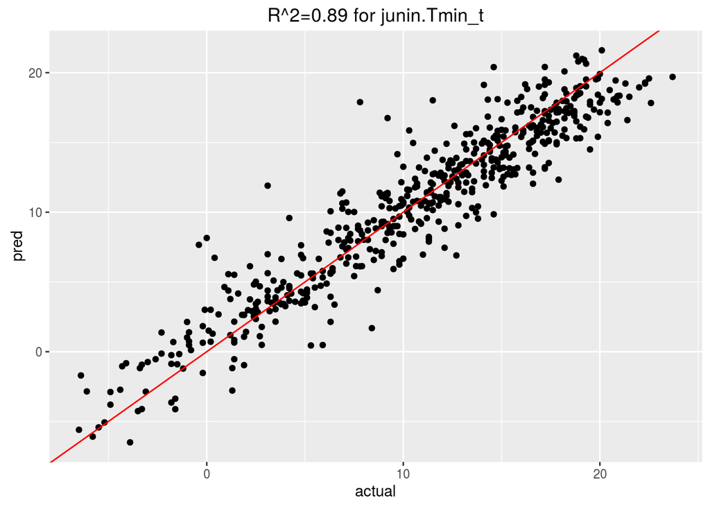

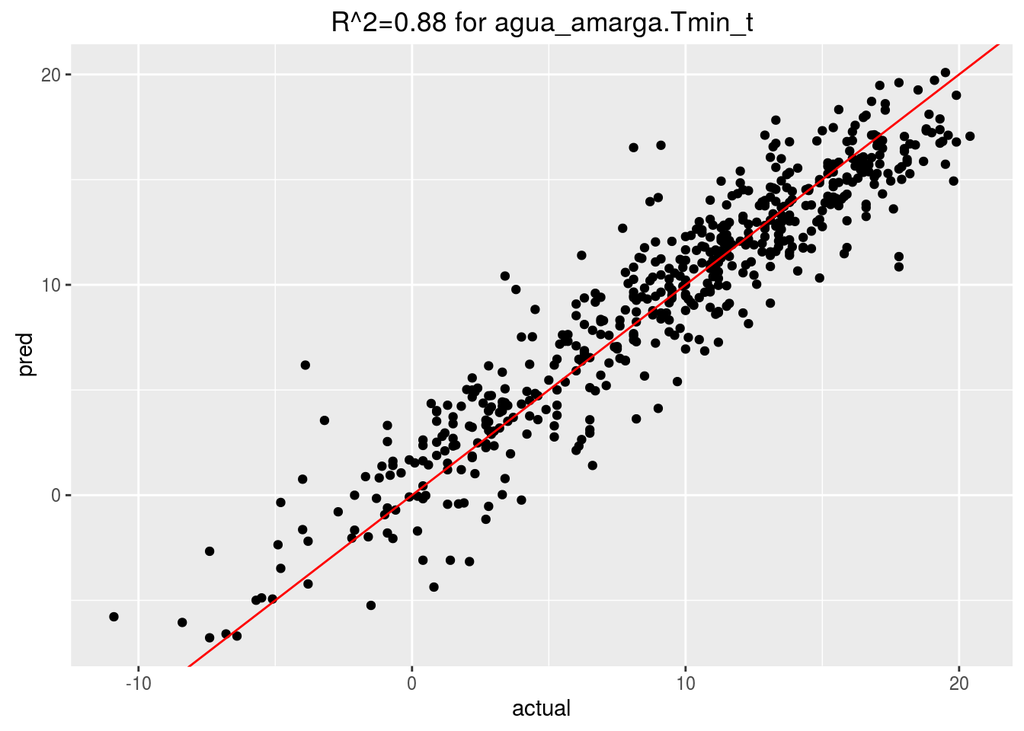

```r
r2_plots_inline(pred_sensores, fitted, test.set)
```

llamar confusionMatrix de caret, pasar primero “a factor of predicted classes, then a factor of classes to be used as the true results

```r
breaks.binario <- c(-10,0,50) # caso Helada y no helada
my.breaks <- c(-10,-5,0,2,5,10,50)
```

### Caso binario: helada o no helada

```r
conf_matrix_binario = conf_matrix(fitted,pred_sensores,test.set, breaks.binario)
```

```
## Variable  las_paredes.Tmin_t
## Confusion Matrix and Statistics
##
##           Reference
## Prediction (-10,0] (0,50]
##    (-10,0]       0      3
##    (0,50]        6    534
##
##                Accuracy : 0.9834
##                  95% CI : (0.9688, 0.9924)
##     No Information Rate : 0.989
##     P-Value [Acc > NIR] : 0.9172
##
##                   Kappa : -0.0074
##  Mcnemar's Test P-Value : 0.5050
##
##             Sensitivity : 0.000000
##             Specificity : 0.994413
##          Pos Pred Value : 0.000000
##          Neg Pred Value : 0.988889
##              Prevalence : 0.011050
##          Detection Rate : 0.000000
##    Detection Prevalence : 0.005525
##       Balanced Accuracy : 0.497207
##
##        'Positive' Class : (-10,0]
##
## Variable  la_llave.Tmin_t
## Confusion Matrix and Statistics
##
##           Reference
## Prediction (-10,0] (0,50]
##    (-10,0]       2      2
##    (0,50]        2    537
##
##                Accuracy : 0.9926
##                  95% CI : (0.9812, 0.998)
##     No Information Rate : 0.9926
##     P-Value [Acc > NIR] : 0.6288
##
```

[output cut: 80 more lines]

```
##
##                   Kappa : 0.6398
##  Mcnemar's Test P-Value : 1.00000
##
##             Sensitivity : 0.67500
##             Specificity : 0.97211
##          Pos Pred Value : 0.65854
##          Neg Pred Value : 0.97405
##              Prevalence : 0.07380
##          Detection Rate : 0.04982
##    Detection Prevalence : 0.07565
##       Balanced Accuracy : 0.82356
##
##        'Positive' Class : (-10,0]
##
```

### Evaluación de predicción en rangos de temperaturas

```r
conf_matrix_temp = conf_matrix(fitted,pred_sensores,test.set, my.breaks)
```

```
## Variable  las_paredes.Tmin_t
## Confusion Matrix and Statistics
##
##           Reference
## Prediction (-10,-5] (-5,0] (0,2] (2,5] (5,10] (10,50]
##   (-10,-5]        0      0     0     0      0       0
##   (-5,0]          0      0     2     1      0       0
##   (0,2]           0      3     2     1      0       0
##   (2,5]           0      1     1     4      3       1
##   (5,10]          0      1     1    14     37      20
##   (10,50]         0      1     0     3     28     419
##
## Overall Statistics
##
##                Accuracy : 0.8508
##                  95% CI : (0.818, 0.8797)
##     No Information Rate : 0.8103
##     P-Value [Acc > NIR] : 0.007954
##
##                   Kappa : 0.5175
##  Mcnemar's Test P-Value : NA
##
## Statistics by Class:
##
##                      Class: (-10,-5] Class: (-5,0] Class: (0,2]
## Sensitivity                       NA      0.000000     0.333333
## Specificity                        1      0.994413     0.992551
## Pos Pred Value                    NA      0.000000     0.333333
## Neg Pred Value                    NA      0.988889     0.992551
## Prevalence                         0      0.011050     0.011050
## Detection Rate                     0      0.000000     0.003683
## Detection Prevalence               0      0.005525     0.011050
## Balanced Accuracy                 NA      0.497207     0.662942
##                      Class: (2,5] Class: (5,10] Class: (10,50]
## Sensitivity              0.173913       0.54412         0.9523
## Specificity              0.988462       0.92421         0.6893
## Pos Pred Value           0.400000       0.50685         0.9290
## Neg Pred Value           0.964353       0.93404         0.7717
## Prevalence               0.042357       0.12523         0.8103
## Detection Rate           0.007366       0.06814         0.7716
```

[output cut: 155 more lines]

```
## Pos Pred Value              0.800000       0.50000      0.33333
## Neg Pred Value              0.992551       0.97233      0.94595
## Prevalence                  0.014760       0.05904      0.06642
## Detection Rate              0.007380       0.03321      0.01476
## Detection Prevalence        0.009225       0.06642      0.04428
## Balanced Accuracy           0.749064       0.76360      0.59530
##                      Class: (2,5] Class: (5,10] Class: (10,50]
## Sensitivity               0.63934        0.6484         0.9206
## Specificity               0.93139        0.9155         0.8792
## Pos Pred Value            0.54167        0.7034         0.8885
## Neg Pred Value            0.95319        0.8939         0.9137
## Prevalence                0.11255        0.2362         0.5111
## Detection Rate            0.07196        0.1531         0.4705
## Detection Prevalence      0.13284        0.2177         0.5295
## Balanced Accuracy         0.78537        0.7819         0.8999
```

Test de predicción con randomForest

```r
library(randomForest)
```

```
## Variable  las_paredes.Tmin_t  MSE: 10.09489  Rsquared:  0.7739493
```

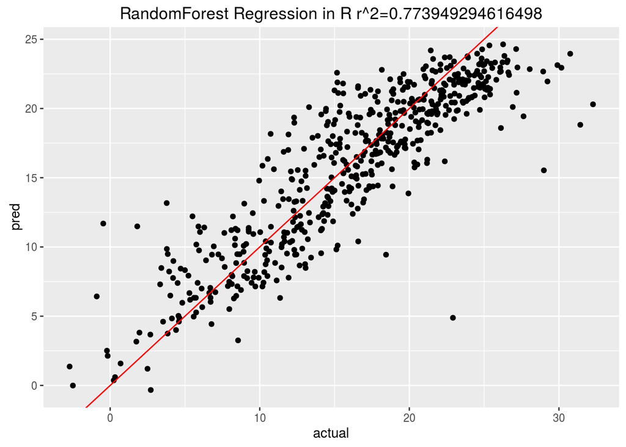

```
## Confusion matrix helada/no helada la_llave.Tmin_t
## Confusion Matrix and Statistics
##
##           Reference
## Prediction (-10,0] (0,50]
##    (-10,0]       1      1
##    (0,50]        5    536
##
##                Accuracy : 0.989
##                  95% CI : (0.9761, 0.9959)
##     No Information Rate : 0.989
##     P-Value [Acc > NIR] : 0.6063
##
##                   Kappa : 0.2458
##  Mcnemar's Test P-Value : 0.2207
##
##             Sensitivity : 0.166667
##             Specificity : 0.998138
##          Pos Pred Value : 0.500000
##          Neg Pred Value : 0.990758
##              Prevalence : 0.011050
##          Detection Rate : 0.001842
##    Detection Prevalence : 0.003683
##       Balanced Accuracy : 0.582402
##
##        'Positive' Class : (-10,0]
##
## Confusion matrix  las_paredes.Tmin_t
## Confusion Matrix and Statistics
##
##           Reference
## Prediction (-10,-5] (-5,0] (0,2] (2,5] (5,10] (10,50]
##   (-10,-5]        0      0     0     0      0       0
##   (-5,0]          0      1     0     1      0       0
##   (0,2]           0      1     3     1      0       0
##   (2,5]           0      2     2     7      3       1
##   (5,10]          0      1     0    13     43      27
##   (10,50]         0      1     1     1     22     412
##
## Overall Statistics
```

[output cut: 15 more lines]

```
## Neg Pred Value                    NA      0.990758     0.994424
## Prevalence                         0      0.011050     0.011050
## Detection Rate                     0      0.001842     0.005525
## Detection Prevalence               0      0.003683     0.009208
## Balanced Accuracy                 NA      0.582402     0.748138
##                      Class: (2,5] Class: (5,10] Class: (10,50]
## Sensitivity               0.30435       0.63235         0.9364
## Specificity               0.98462       0.91368         0.7573
## Pos Pred Value            0.46667       0.51190         0.9428
## Neg Pred Value            0.96970       0.94553         0.7358
## Prevalence                0.04236       0.12523         0.8103
## Detection Rate            0.01289       0.07919         0.7587
## Detection Prevalence      0.02762       0.15470         0.8048
## Balanced Accuracy         0.64448       0.77302         0.8468
## Variable  la_llave.Tmin_t  MSE: 8.424572  Rsquared:  0.8233744
```

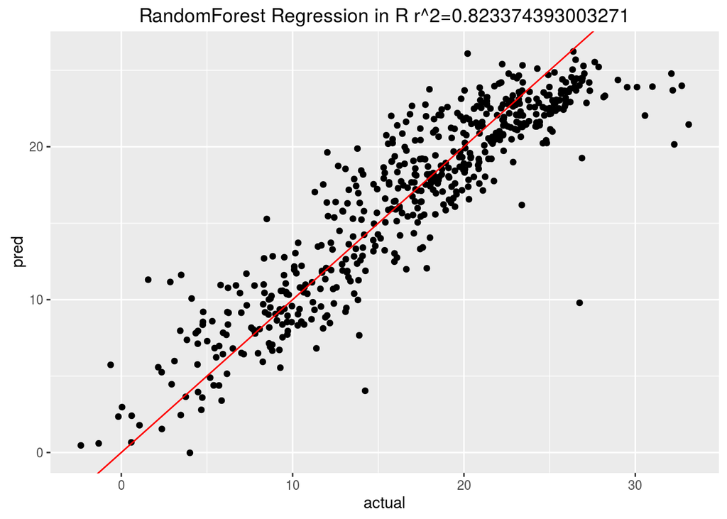

```
## Confusion matrix helada/no helada la_llave.Tmin_t
## Confusion Matrix and Statistics
##
##           Reference
## Prediction (-10,0] (0,50]
##    (-10,0]       0      1
##    (0,50]        4    538
##
##                Accuracy : 0.9908
##                  95% CI : (0.9786, 0.997)
##     No Information Rate : 0.9926
##     P-Value [Acc > NIR] : 0.7857
##
##                   Kappa : -0.003
##  Mcnemar's Test P-Value : 0.3711
##
##             Sensitivity : 0.000000
##             Specificity : 0.998145
##          Pos Pred Value : 0.000000
##          Neg Pred Value : 0.992620
##              Prevalence : 0.007366
##          Detection Rate : 0.000000
##    Detection Prevalence : 0.001842
##       Balanced Accuracy : 0.499072
##
##        'Positive' Class : (-10,0]
##
## Confusion matrix  la_llave.Tmin_t
## Confusion Matrix and Statistics
##
##           Reference
## Prediction (-10,-5] (-5,0] (0,2] (2,5] (5,10] (10,50]
##   (-10,-5]        0      0     0     0      0       0
##   (-5,0]          0      0     0     1      0       0
##   (0,2]           0      2     2     1      0       0
##   (2,5]           0      1     2     6      4       1
##   (5,10]          0      1     0    12     47      20
##   (10,50]         0      0     1     3     22     417
##
## Overall Statistics
```

[output cut: 15 more lines]

```
## Neg Pred Value                    NA      0.992620     0.994424
## Prevalence                         0      0.007366     0.009208
## Detection Rate                     0      0.000000     0.003683
## Detection Prevalence               0      0.001842     0.009208
## Balanced Accuracy                 NA      0.499072     0.697212
##                      Class: (2,5] Class: (5,10] Class: (10,50]
## Sensitivity               0.26087       0.64384         0.9521
## Specificity               0.98462       0.92979         0.7524
## Pos Pred Value            0.42857       0.58750         0.9413
## Neg Pred Value            0.96786       0.94384         0.7900
## Prevalence                0.04236       0.13444         0.8066
## Detection Rate            0.01105       0.08656         0.7680
## Detection Prevalence      0.02578       0.14733         0.8158
## Balanced Accuracy         0.62274       0.78681         0.8522
## Variable  tunuyan.Tmin_t  MSE: 5.099888  Rsquared:  0.8866792
```

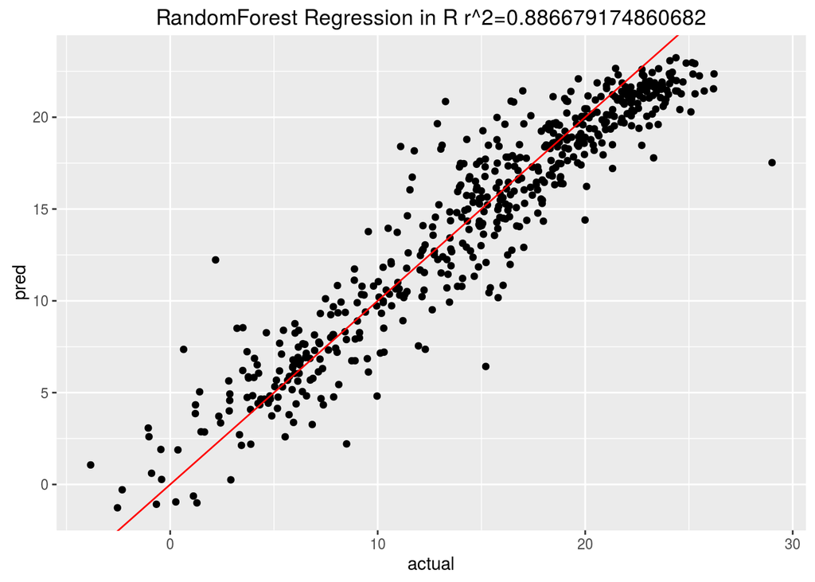

```
## Confusion matrix helada/no helada la_llave.Tmin_t
## Confusion Matrix and Statistics
##
##           Reference
## Prediction (-10,0] (0,50]
##    (-10,0]       3      3
##    (0,50]        6    531
##
##                Accuracy : 0.9834
##                  95% CI : (0.9688, 0.9924)
##     No Information Rate : 0.9834
##     P-Value [Acc > NIR] : 0.5874
##
##                   Kappa : 0.3919
##  Mcnemar's Test P-Value : 0.5050
##
##             Sensitivity : 0.333333
##             Specificity : 0.994382
##          Pos Pred Value : 0.500000
##          Neg Pred Value : 0.988827
##              Prevalence : 0.016575
##          Detection Rate : 0.005525
##    Detection Prevalence : 0.011050
##       Balanced Accuracy : 0.663858
##
##        'Positive' Class : (-10,0]
##
## Confusion matrix  tunuyan.Tmin_t
## Confusion Matrix and Statistics
##
##           Reference
## Prediction (-10,-5] (-5,0] (0,2] (2,5] (5,10] (10,50]
##   (-10,-5]        0      0     0     0      0       0
##   (-5,0]          0      3     3     0      0       0
##   (0,2]           0      4     1     1      0       0
##   (2,5]           0      2     4    19     13       0
##   (5,10]          0      0     2    12     67      13
##   (10,50]         0      0     0     1      9     389
##
## Overall Statistics
```

[output cut: 15 more lines]

```
## Neg Pred Value                    NA      0.988827     0.983240
## Prevalence                         0      0.016575     0.018416
## Detection Rate                     0      0.005525     0.001842
## Detection Prevalence               0      0.011050     0.011050
## Balanced Accuracy                 NA      0.663858     0.545310
##                      Class: (2,5] Class: (5,10] Class: (10,50]
## Sensitivity               0.57576        0.7528         0.9677
## Specificity               0.96275        0.9405         0.9291
## Pos Pred Value            0.50000        0.7128         0.9749
## Neg Pred Value            0.97228        0.9510         0.9097
## Prevalence                0.06077        0.1639         0.7403
## Detection Rate            0.03499        0.1234         0.7164
## Detection Prevalence      0.06998        0.1731         0.7348
## Balanced Accuracy         0.76925        0.8467         0.9484
## Variable  junin.Tmin_t  MSE: 5.240279  Rsquared:  0.8798047
```

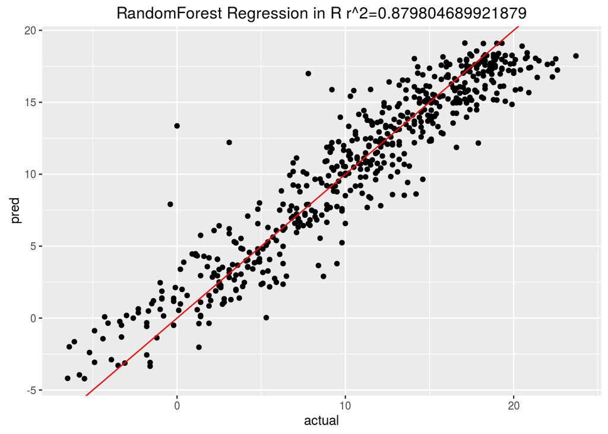

```
## Confusion matrix helada/no helada la_llave.Tmin_t
## Confusion Matrix and Statistics
##
##           Reference
## Prediction (-10,0] (0,50]
##    (-10,0]      24      3
##    (0,50]       18    498
##
##                Accuracy : 0.9613
##                  95% CI : (0.9415, 0.9759)
##     No Information Rate : 0.9227
##     P-Value [Acc > NIR] : 0.0001688
##
##                   Kappa : 0.676
##  Mcnemar's Test P-Value : 0.0022502
##
##             Sensitivity : 0.57143
##             Specificity : 0.99401
##          Pos Pred Value : 0.88889
##          Neg Pred Value : 0.96512
##              Prevalence : 0.07735
##          Detection Rate : 0.04420
##    Detection Prevalence : 0.04972
##       Balanced Accuracy : 0.78272
##
##        'Positive' Class : (-10,0]
##
## Confusion matrix  junin.Tmin_t
## Confusion Matrix and Statistics
##
##           Reference
## Prediction (-10,-5] (-5,0] (0,2] (2,5] (5,10] (10,50]
##   (-10,-5]        0      0     0     0      0       0
##   (-5,0]          6     18     3     0      0       0
##   (0,2]           0     14    11     8      1       0
##   (2,5]           0      2    10    36     16       0
##   (5,10]          0      1     1    11     66      17
##   (10,50]         0      1     0     1     27     293
##
## Overall Statistics
```

[output cut: 15 more lines]

```
## Neg Pred Value               0.98895       0.96512      0.97250
## Prevalence                   0.01105       0.06630      0.04604
## Detection Rate               0.00000       0.03315      0.02026
## Detection Prevalence         0.00000       0.04972      0.06262
## Balanced Accuracy            0.50000       0.74112      0.69780
##                      Class: (2,5] Class: (5,10] Class: (10,50]
## Sensitivity                0.6429        0.6000         0.9452
## Specificity                0.9425        0.9307         0.8755
## Pos Pred Value             0.5625        0.6875         0.9099
## Neg Pred Value             0.9582        0.9016         0.9231
## Prevalence                 0.1031        0.2026         0.5709
## Detection Rate             0.0663        0.1215         0.5396
## Detection Prevalence       0.1179        0.1768         0.5930
## Balanced Accuracy          0.7927        0.7654         0.9103
## Variable  agua_amarga.Tmin_t  MSE: 4.623978  Rsquared:  0.8768158
```

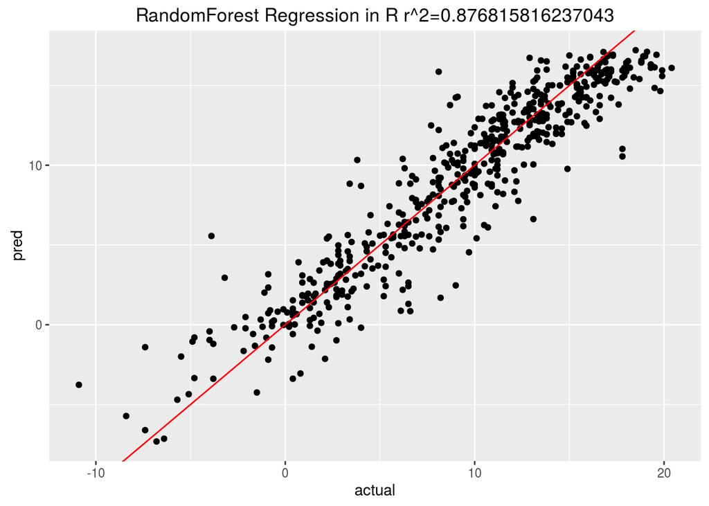

```
## Confusion matrix helada/no helada la_llave.Tmin_t
## Confusion Matrix and Statistics
##
##           Reference
## Prediction (-10,0] (0,50]
##    (-10,0]      27     10
##    (0,50]       13    492
##
##                Accuracy : 0.9576
##                  95% CI : (0.937, 0.9729)
##     No Information Rate : 0.9262
##     P-Value [Acc > NIR] : 0.001889
##
##                   Kappa : 0.6785
##  Mcnemar's Test P-Value : 0.676657
##
##             Sensitivity : 0.67500
##             Specificity : 0.98008
##          Pos Pred Value : 0.72973
##          Neg Pred Value : 0.97426
##              Prevalence : 0.07380
##          Detection Rate : 0.04982
##    Detection Prevalence : 0.06827
##       Balanced Accuracy : 0.82754
##
##        'Positive' Class : (-10,0]
##
## Confusion matrix  agua_amarga.Tmin_t
## Confusion Matrix and Statistics
##
##           Reference
## Prediction (-10,-5] (-5,0] (0,2] (2,5] (5,10] (10,50]
##   (-10,-5]        4      0     0     0      0       0
##   (-5,0]          4     19     7     3      0       0
##   (0,2]           0      8    22    10      5       0
##   (2,5]           0      4     7    36     16       0
##   (5,10]          0      1     0    11     78      23
##   (10,50]         0      0     0     1     29     254
##
## Overall Statistics
```

[output cut: 14 more lines]

```
## Pos Pred Value               1.00000       0.57576      0.48889
## Neg Pred Value               0.99257       0.97446      0.97183
## Prevalence                   0.01476       0.05904      0.06642
## Detection Rate               0.00738       0.03506      0.04059
## Detection Prevalence         0.00738       0.06089      0.08303
## Balanced Accuracy            0.75000       0.78315      0.78283
##                      Class: (2,5] Class: (5,10] Class: (10,50]
## Sensitivity               0.59016        0.6094         0.9170
## Specificity               0.94387        0.9155         0.8868
## Pos Pred Value            0.57143        0.6903         0.8944
## Neg Pred Value            0.94781        0.8834         0.9109
## Prevalence                0.11255        0.2362         0.5111
## Detection Rate            0.06642        0.1439         0.4686
## Detection Prevalence      0.11624        0.2085         0.5240
## Balanced Accuracy         0.76702        0.7624         0.9019
```

```r
library(miscTools)
library(ggplot2)


for(i in 1:length(pred_sensores))
{
  # determinar la variable predictora
  y_label <- pred_sensores[i]
  df2 <- df
  #' renombro variable predictora por y, para facilitar formula
  colnames(df2)[which(colnames(df2)==y_label)] <- "y"
  #' quito las otras variables predictoras, ya que solo analizaré la que se encuentre en y_label
  #'
  df2 <- df2[,-which(names(df2) %in% pred_sensores)]
  colnames(df2)

  # train y test set
  until <- round(nrow(df2)*.67)
  training.set = df2[1:until, ] # This is training set to learn the parameters
  test.set = df2[until:nrow(df2), ]


  model <- randomForest(y ~ ., data = training.set, importance = TRUE )
  pred <- predict(model, test.set)
  #View(cbind(pred,test.set$y))
  mse <- mean((test.set$y - pred)^2)
  r2 <- rSquared(test.set$y, test.set$y - pred)

  cat("Variable ",pred_sensores[i]," MSE:",mse," Rsquared: ",r2)

  #' Plot R_2, valores predichos vs valores reales
  #'

  p <- ggplot(aes(x=actual, y=pred),
              data=data.frame(actual=test.set$y, pred=pred))
  p2 <- p + geom_point() +
    geom_abline(color="red") +
    ggtitle(paste("RandomForest Regression in R r^2=", r2, sep=""))

  plot(p2)

  cat("Confusion matrix helada/no helada",pred_sensores[2],"\n")

  y <- cut(test.set[,"y"], breaks = breaks.binario)
  y_pred <- cut(pred, breaks = breaks.binario)
  print(confusionMatrix(y_pred,y))

  cat("Confusion matrix ",pred_sensores[i],"\n")
  y <- cut(test.set[, "y"], breaks = my.breaks)
  y_pred <- cut(pred, breaks = my.breaks)
  print(confusionMatrix(y_pred,y))


}
```

## Oversampling: generamos más datos en el training.set mediante SMOTE

Para ello dividimos el dataset entre training y testing. En el training set aplicamos SMOTE.

genero etiquetas: 1 noche de helada y 0 no helada por cada estación, ya que tienen distintos datos de heladas

Luego evaluamos para cada una como resultó la predicción

```r
# for(j in 1:length(pred_sensores))
# {
#
#   sensor <- unlist(strsplit(pred_sensores[i],split=".",fixed = TRUE))[1]
#   vars <- v[grepl( sensor, v, fixed = TRUE)] # extraigo todas las variables relacionadas con sensor
#   #vars <- vars[-length(vars)] # quito la última variable min_t
#
# }
```

Me enfoco en el caso de la estación junin, por lo que analizaremos solo la predicción sobre la misma….

```r
var_pred <- pred_sensores[4]
Y_class <- as.factor(with(df,ifelse(df[,pred_sensores[4]] <= 0,1,0)))

hasta <- round(nrow(df)*.67)
hasta
```

```
## [1] 1101
```

```r
summary(Y_class)
```

```
##    0    1
## 1459  184
```

```r
summary(Y_class[hasta:length(Y_class)])
```

```
##   0   1
## 501  42
```

```r
test.set <- df[hasta:nrow(df),]
```

```r
library(unbalanced)
```

datos para entrenar

```r
data_smote <- ubBalance(df[1:(hasta-1),],Y_class[1:(hasta-1)],type = "ubSMOTE",percOver = 300, percUnder = 150)
```

para visualizar la distribución de las clases

```r
summary(data_smote$Y)
```

```
##   0   1
## 639 568
```

```r
training.set <- data_smote$X
```

Procedemos a realizar las predicciones y evaluar el error.

Aprendemos una red bayesiana usando el algoritmo hc y pasando como restricciones las white y black lists

```r
start_time <- Sys.time()
print(start_time)
```

```
## [1] "2017-10-11 13:00:42 ART"
```

```r
res = hc(training.set, whitelist=wl,blacklist = bl) # , cluster = cl) # no funciona esta funcion de cluster
end_time <- Sys.time()
end_time - start_time
```

```
## Time difference of 27.32648 secs
```

guardar modelo

```r
save(res, file= paste("hc-dacc-smote-t2",var_pred,"-",Sys.time(),".RData",sep=""))
```

Aprendizaje de parametros

```r
start_time <- Sys.time()
fitted = bn.fit(res, training.set)     # learning of parameters
end_time <- Sys.time()
end_time - start_time
```

```
## Time difference of 0.1167457 secs
```

Mostramos los parámetros para los nodos que nos interesan predecir

```r
fitted[pred_sensores]
```

```
## $las_paredes.Tmin_t
##
##   Parameters of node las_paredes.Tmin_t (Gaussian distribution)
##
## Conditional density: las_paredes.Tmin_t | las_paredes.Hmin_T_2 + las_paredes.Hmed_T_2 + las_paredes.Hmax_T_2 + las_paredes.Tmin_T_2 + las_paredes.Tmax_T_2 + las_paredes.Tmed_T_2 + tunuyan.Hmax_T_2 + tunuyan.Tmin_T_2 + el_marcado.Tmed_T_2 + el_marcado.Tmin_T_2 + las_paredes.Hmin_T_1 + las_paredes.…
## Coefficients:
##          (Intercept)  las_paredes.Hmin_T_2  las_paredes.Hmed_T_2
##          -3.10331668           -0.31417310            0.26442184
## las_paredes.Hmax_T_2  las_paredes.Tmin_T_2  las_paredes.Tmax_T_2
##           0.03151265            0.31506848            0.25103617
## las_paredes.Tmed_T_2      tunuyan.Hmax_T_2      tunuyan.Tmin_T_2
##          -0.71059571            0.02285139            0.19382535
##  el_marcado.Tmed_T_2   el_marcado.Tmin_T_2  las_paredes.Hmin_T_1
##          -0.13448654            0.15468701            0.09406736
## las_paredes.Hmed_T_1  las_paredes.Hmax_T_1  las_paredes.Tmin_T_1
##           0.26794359           -0.33455390           -0.37928254
## las_paredes.Tmax_T_1  las_paredes.Tmed_T_1     la_llave.Tmax_T_1
##          -0.24978490            0.74396581            0.33441472
## agua_amarga.Tmax_T_1   el_marcado.Tmax_T_1
##           0.23423241            0.15168829
## Standard deviation of the residuals: 2.354772
##
## $la_llave.Tmin_t
##
##   Parameters of node la_llave.Tmin_t (Gaussian distribution)
##
## Conditional density: la_llave.Tmin_t | la_llave.Hmin_T_2 + la_llave.Hmed_T_2 + la_llave.Hmax_T_2 + la_llave.Tmin_T_2 + la_llave.Tmax_T_2 + la_llave.Tmed_T_2 + tunuyan.Tmin_T_2 + las_paredes.Hmin_T_1 + las_paredes.Hmax_T_1 + la_llave.Hmin_T_1 + la_llave.Hmed_T_1 + la_llave.Hmax_T_1 + la_llave.Tmin…
## Coefficients:
##          (Intercept)     la_llave.Hmin_T_2     la_llave.Hmed_T_2
##           -1.3218603             0.1609400            -1.0683128
##    la_llave.Hmax_T_2     la_llave.Tmin_T_2     la_llave.Tmax_T_2
##            0.8771802             2.0137051            -0.8251169
##    la_llave.Tmed_T_2      tunuyan.Tmin_T_2  las_paredes.Hmin_T_1
##           -1.2778640             0.1968943             0.2279577
## las_paredes.Hmax_T_1     la_llave.Hmin_T_1     la_llave.Hmed_T_1
##           -0.2010723             0.5818554            -1.1759686
##    la_llave.Hmax_T_1     la_llave.Tmin_T_1     la_llave.Tmax_T_1
##            0.6017478             0.7959811             0.1193294
##    la_llave.Tmed_T_1  agua_amarga.Tmax_T_1   el_marcado.Tmax_T_1
##           -0.5042839             0.1801126             0.2735971
```

[output cut: 54 more lines]

```
##          (Intercept)      tunuyan.Tmed_T_2  agua_amarga.Tmax_T_2
##         -9.933280620           0.146953677          -0.124331928
## agua_amarga.Tmed_T_2  agua_amarga.Tmin_T_2  agua_amarga.Hmax_T_2
##         -0.196642792           0.116565004           0.002897231
## agua_amarga.Hmed_T_2  agua_amarga.Hmin_T_2  las_paredes.Tmed_T_1
##         -0.002997950          -0.043936676           0.134986591
##    la_llave.Tmin_T_1        junin.Tmed_T_1        junin.Tmin_T_1
##          0.148237746           0.274529172           0.139694895
##       junin.Hmin_T_1  agua_amarga.Tmax_T_1  agua_amarga.Tmed_T_1
##          0.042091884           0.228439914           0.035325652
## agua_amarga.Tmin_T_1  agua_amarga.Hmax_T_1  agua_amarga.Hmed_T_1
##         -0.023465754          -0.052197871           0.143846497
## agua_amarga.Hmin_T_1   el_marcado.Tmax_T_1
##         -0.037911901           0.102044426
## Standard deviation of the residuals: 1.836097
```

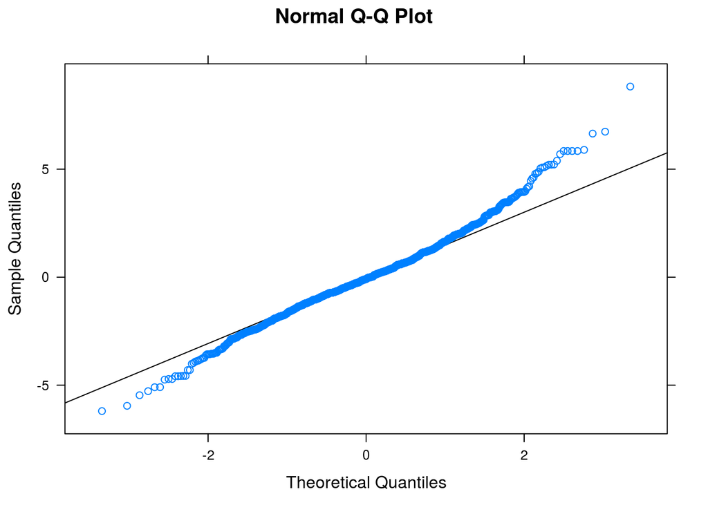

```r
bn.fit.qqplot(fitted[[ncol(df)]])
```

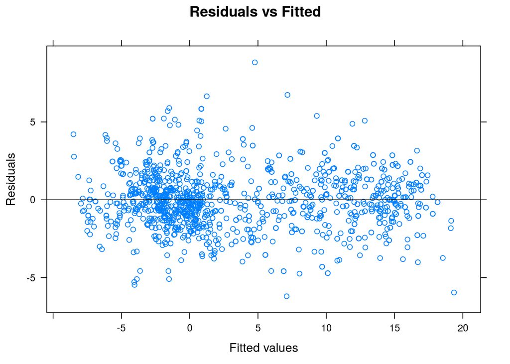

```r
bn.fit.xyplot(fitted[[ncol(df)]])
```

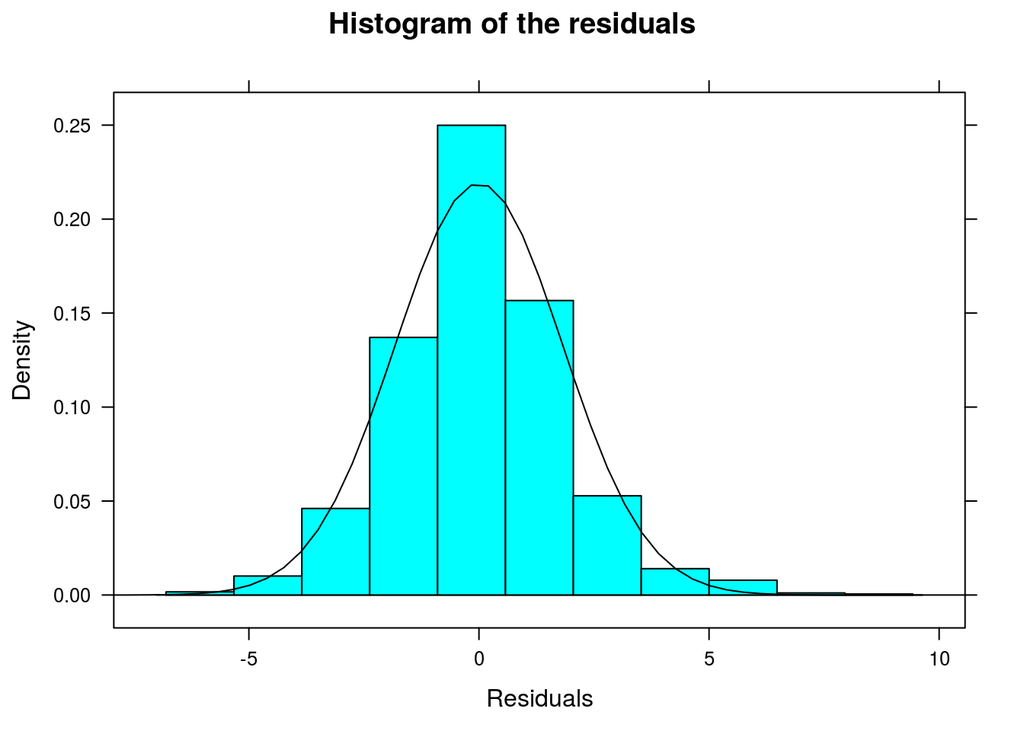

```r
bn.fit.histogram(fitted[[ncol(df)]])
```

Markov blanket de las variables de interés para predecir

```r
for(i in 1:length(pred_sensores))
{
  cat("Markov blanket of ",pred_sensores[i],"\n")
  print(mb(res,pred_sensores[i]))
}
```

```
## Markov blanket of  las_paredes.Tmin_t
##  [1] "las_paredes.Hmin_T_2" "las_paredes.Hmed_T_2" "las_paredes.Hmax_T_2"
##  [4] "las_paredes.Tmin_T_2" "las_paredes.Tmax_T_2" "las_paredes.Tmed_T_2"
##  [7] "la_llave.Tmax_T_2"    "la_llave.Tmed_T_2"    "tunuyan.Hmin_T_2"
## [10] "tunuyan.Hmed_T_2"     "tunuyan.Hmax_T_2"     "tunuyan.Tmin_T_2"
## [13] "tunuyan.Tmed_T_2"     "junin.Tmed_T_2"       "junin.Tmin_T_2"
## [16] "junin.Hmax_T_2"       "junin.Hmed_T_2"       "junin.Hmin_T_2"
## [19] "agua_amarga.Tmax_T_2" "agua_amarga.Tmin_T_2" "agua_amarga.Hmax_T_2"
## [22] "agua_amarga.Hmed_T_2" "el_marcado.Tmax_T_2"  "el_marcado.Tmed_T_2"
## [25] "el_marcado.Tmin_T_2"  "el_marcado.Hmed_T_2"  "el_marcado.Hmin_T_2"
## [28] "las_paredes.Hmin_T_1" "las_paredes.Hmed_T_1" "las_paredes.Hmax_T_1"
## [31] "las_paredes.Tmin_T_1" "las_paredes.Tmax_T_1" "las_paredes.Tmed_T_1"
## [34] "la_llave.Hmin_T_1"    "la_llave.Hmed_T_1"    "la_llave.Hmax_T_1"
## [37] "la_llave.Tmax_T_1"    "tunuyan.Hmin_T_1"     "tunuyan.Hmed_T_1"
## [40] "tunuyan.Hmax_T_1"     "tunuyan.Tmin_T_1"     "tunuyan.Tmax_T_1"
```

[output cut: 51 more lines]

Predicciones, evaluación en conjunto de testeo, caso regresión predicción temperaturas

```r
df_res <- errors_regression(var_pred, fitted, test.set, verbose = FALSE)
```

```
## Testing on  junin.Tmin_t
```

```r
df_res
```

```
##       Variable               ME             RMSE              MAE  MPE
## 1 junin.Tmin_t 0.30605200137322 2.24678867536946 1.67727350109258 -Inf
##   MAPE
## 1  Inf
```

plots de R squared

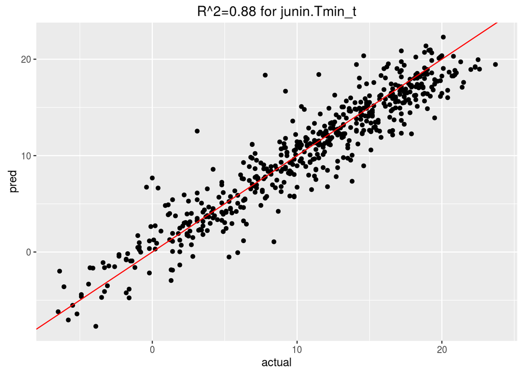

```r
r2_plots_inline(var_pred, fitted, test.set)
```

llamar confusionMatrix de caret, pasar primero “a factor of predicted classes, then a factor of classes to be used as the true results

```r
breaks.binario <- c(-10,0,50) # caso Helada y no helada
my.breaks <- c(-10,-5,0,2,5,10,50)
```

### Caso binario: helada o no helada

```r
conf_matrix_binario = conf_matrix(fitted,var_pred,test.set, breaks.binario)
```

```
## Variable  junin.Tmin_t
## Confusion Matrix and Statistics
##
##           Reference
## Prediction (-10,0] (0,50]
##    (-10,0]      32      7
##    (0,50]       10    494
##
##                Accuracy : 0.9687
##                  95% CI : (0.9503, 0.9817)
##     No Information Rate : 0.9227
##     P-Value [Acc > NIR] : 5.572e-06
##
##                   Kappa : 0.7732
##  Mcnemar's Test P-Value : 0.6276
##
##             Sensitivity : 0.76190
##             Specificity : 0.98603
##          Pos Pred Value : 0.82051
##          Neg Pred Value : 0.98016
##              Prevalence : 0.07735
##          Detection Rate : 0.05893
##    Detection Prevalence : 0.07182
##       Balanced Accuracy : 0.87397
##
##        'Positive' Class : (-10,0]
##
```

### Evaluación de predicción en rangos de temperaturas

```r
conf_matrix_temp = conf_matrix(fitted,var_pred,test.set, my.breaks)
```

```
## Variable  junin.Tmin_t
## Confusion Matrix and Statistics
##
##           Reference
## Prediction (-10,-5] (-5,0] (0,2] (2,5] (5,10] (10,50]
##   (-10,-5]        4      1     0     0      0       0
##   (-5,0]          2     25     4     1      2       0
##   (0,2]           0      7    11     6      2       0
##   (2,5]           0      1     8    36     14       0
##   (5,10]          0      2     2    12     70      26
##   (10,50]         0      0     0     1     22     284
##
## Overall Statistics
##
##                Accuracy : 0.7919
##                  95% CI : (0.7553, 0.8253)
##     No Information Rate : 0.5709
##     P-Value [Acc > NIR] : < 2.2e-16
##
##                   Kappa : 0.6631
##  Mcnemar's Test P-Value : NA
##
## Statistics by Class:
##
##                      Class: (-10,-5] Class: (-5,0] Class: (0,2]
## Sensitivity                 0.666667       0.69444      0.44000
## Specificity                 0.998138       0.98225      0.97104
## Pos Pred Value              0.800000       0.73529      0.42308
## Neg Pred Value              0.996283       0.97839      0.97292
## Prevalence                  0.011050       0.06630      0.04604
## Detection Rate              0.007366       0.04604      0.02026
## Detection Prevalence        0.009208       0.06262      0.04788
## Balanced Accuracy           0.832402       0.83835      0.70552
##                      Class: (2,5] Class: (5,10] Class: (10,50]
## Sensitivity                0.6429        0.6364         0.9161
## Specificity                0.9528        0.9030         0.9013
## Pos Pred Value             0.6102        0.6250         0.9251
## Neg Pred Value             0.9587        0.9072         0.8898
## Prevalence                 0.1031        0.2026         0.5709
## Detection Rate             0.0663        0.1289         0.5230
## Detection Prevalence       0.1087        0.2063         0.5654
## Balanced Accuracy          0.7978        0.7697         0.9087
```